# Clean Data

Jessica Scarborough

7/21/2021

```r
library(janitor)
library(knitr)
library(here)
library(tidyverse)
```

First, we’ll need to set our drug of interest here as `drug`. This will be important for filtering cell lines in the GDSC and creating directories to store data and results.

```r
drug <- "Cisplatin"
```

First we’ll create the appropriate drug-specific directories in our project.

```r
dir.create(here("Data"), showWarnings = FALSE)
dir.create(here("Data", drug), showWarnings = FALSE)
dir.create(here("Results"), showWarnings = FALSE)
dir.create(here("Results", drug), showWarnings = FALSE)
dir.create(here("Results", drug, "Coexpression"), showWarnings = FALSE)
dir.create(here("Results", drug, "DE"), showWarnings = FALSE)
dir.create(here("Results", drug, "Prediction_Modeling"), showWarnings = FALSE)
dir.create(here("Results", drug, "Plots"), showWarnings = FALSE)
dir.create(here("Results", drug, "Plots", "Linear_Models"), showWarnings = FALSE)
dir.create(here("Results", drug, "Plots", "ROC_Curves"), showWarnings = FALSE)
dir.create(here("Results", drug, "Plots", "Null_Model_Metrics"), showWarnings = FALSE)
dir.create(here("Results", drug, "Plots", "External_Clinical_Testing"), showWarnings = FALSE)
```

Here, we’ll clean the data downloaded with the `download_data.Rmd` file.

# TCGA

Read in all the TCGA subtypes to be included in our epithelial TCGA dataset. Each disease site’s file is downloaded using `download_data.Rmd`.

## Clean TCGA RNA Seq V2

```r
tcga_labels <- readRDS(here("Data", "TCGA", "tcga_labels.rds"))

tcga_datalist <- list()

for (site in tcga_labels){
  site_data <- read.csv(file = here("Data", "TCGA", paste0(site, "_rnaseq_rsem.csv")), row.names = 1)
  dup_genes_tcga <- row.names(site_data)[duplicated(row.names(site_data))] # we use this instead of distinct because distinct keeps one of the duplicates
  site_data <- site_data %>%
    tibble::rownames_to_column(var = "gene_name") %>%
    filter(!(gene_name %in% dup_genes_tcga)) %>% # in this case, we don't filter anything out because there are no dups
    # dplyr::distinct(gene_name, .keep_all = TRUE) %>%
    gather(sample_ID, value, -gene_name) %>%
    spread(gene_name, value) %>%
    mutate(tcga_label = site) %>%
    select(sample_ID, tcga_label, everything())
  tcga_datalist[[site]] <- site_data
}

tcga_data <- dplyr::bind_rows(tcga_datalist)
colnames(tcga_data) <- str_replace_all(colnames(tcga_data), "-", "_")

saveRDS(tcga_data, file = here("Data", "TCGA", "compiled_rnaseq_rsem.rds"))

# tcga_data <- readRDS(here("Data", "TCGA", "compiled_rnaseq_rsem.rds"))
```

# Genomics of Drug Sensitivity in Cancer (GDSC)

As above with the TCGA Data, the GDSC data must be downloaded using `download_data.Rmd`.

## Clean metadata

First, we’ll load the meta data and print our options for cell line labels. From that, we’ll list the labels we plan to keep and extract only the cell lines with those labels.

```r
gdsc_meta <- readxl::read_excel(here("Data", "GDSC", "Cell_Lines_Details.xlsx")) %>%
  clean_names()

unique(gdsc_meta$gdsc_tissue_descriptor_2)
```

```
##  [1] "head and neck"                      "oesophagus"
##  [3] "acute_myeloid_leukaemia"            "anaplastic_large_cell_lymphoma"
##  [5] "B_cell_leukemia"                    "B_cell_lymphoma"
##  [7] "Burkitt_lymphoma"                   "chronic_myeloid_leukaemia"
##  [9] "haematopoietic_neoplasm other"      "hairy_cell_leukaemia"
## [11] "Hodgkin_lymphoma"                   "leukemia"
## [13] "lymphoblastic_leukemia"             "lymphoblastic_T_cell_leukaemia"
## [15] "lymphoid_neoplasm other"            "myeloma"
## [17] "T_cell_leukemia"                    "bone_other"
## [19] "chondrosarcoma"                     "ewings_sarcoma"
## [21] "osteosarcoma"                       "breast"
## [23] "biliary_tract"                      "digestive_system_other"
## [25] "large_intestine"                    "liver"
## [27] "stomach"                            "adrenal_gland"
## [29] "kidney"                             "lung_NSCLC_adenocarcinoma"
## [31] "lung_NSCLC_carcinoid"               "lung_NSCLC_large cell"
## [33] "lung_NSCLC_not specified"           "lung_NSCLC_squamous_cell_carcinoma"
## [35] "Lung_other"                         "lung_small_cell_carcinoma"
## [37] "mesothelioma"                       "glioma"
## [39] "medulloblastoma"                    "neuroblastoma"
## [41] "pancreas"                           "melanoma"
## [43] "skin_other"                         "fibrosarcoma"
## [45] "rhabdomyosarcoma"                   "soft_tissue_other"
## [47] "thyroid"                            "Bladder"
## [49] "cervix"                             "endometrium"
## [51] "ovary"                              "prostate"
## [53] "testis"                             "urogenital_system_other"
## [55] "uterus"                             NA
```

```r
labels_epi_gdsc <- c("head and neck", "oesophagus", "breast", "biliary_tract",
                     "large_intestine", "liver", "adrenal_gland",
                     "stomach", "kidney", "lung_NSCLC_adenocarcinoma",
                     "lung_NSCLC_squamous_cell_carcinoma","mesothelioma",
                     "pancreas", "skin_other", "thyroid", "Bladder",
                     "cervix", "endometrium", "ovary", "prostate", "testis",
                     "urogenital_system_other", "uterus")

labels_non_epi_gdsc <- gdsc_meta %>%
  filter(!(gdsc_tissue_descriptor_2 %in% labels_epi_gdsc))
unique(labels_non_epi_gdsc$gdsc_tissue_descriptor_2)
```

```
##  [1] "acute_myeloid_leukaemia"        "anaplastic_large_cell_lymphoma"
##  [3] "B_cell_leukemia"                "B_cell_lymphoma"
##  [5] "Burkitt_lymphoma"               "chronic_myeloid_leukaemia"
##  [7] "haematopoietic_neoplasm other"  "hairy_cell_leukaemia"
##  [9] "Hodgkin_lymphoma"               "leukemia"
## [11] "lymphoblastic_leukemia"         "lymphoblastic_T_cell_leukaemia"
## [13] "lymphoid_neoplasm other"        "myeloma"
## [15] "T_cell_leukemia"                "bone_other"
## [17] "chondrosarcoma"                 "ewings_sarcoma"
## [19] "osteosarcoma"                   "digestive_system_other"
## [21] "lung_NSCLC_carcinoid"           "lung_NSCLC_large cell"
## [23] "lung_NSCLC_not specified"       "Lung_other"
## [25] "lung_small_cell_carcinoma"      "glioma"
## [27] "medulloblastoma"                "neuroblastoma"
## [29] "melanoma"                       "fibrosarcoma"
## [31] "rhabdomyosarcoma"               "soft_tissue_other"
## [33] NA
```

```r
labels_epi_gdsc #show what we are and aren't including
```

```
##  [1] "head and neck"                      "oesophagus"
##  [3] "breast"                             "biliary_tract"
##  [5] "large_intestine"                    "liver"
##  [7] "adrenal_gland"                      "stomach"
##  [9] "kidney"                             "lung_NSCLC_adenocarcinoma"
## [11] "lung_NSCLC_squamous_cell_carcinoma" "mesothelioma"
## [13] "pancreas"                           "skin_other"
## [15] "thyroid"                            "Bladder"
## [17] "cervix"                             "endometrium"
## [19] "ovary"                              "prostate"
## [21] "testis"                             "urogenital_system_other"
## [23] "uterus"
```

```r
gdsc_meta_epi <- gdsc_meta %>%
  filter(gdsc_tissue_descriptor_2 %in% labels_epi_gdsc) %>%
  mutate(cosmic_id = paste0("DATA.", cosmic_identifier)) %>%
  dplyr::select(cosmic_id, tissue_label = gdsc_tissue_descriptor_2, tcga_label = cancer_type_matching_tcga_label)
```

## Clean expression microarray

```r
gdsc_expr <- readr::read_tsv(here("Data", "GDSC", "Cell_line_RMA_proc_basalExp.txt"))
dup_genes_gdsc <- gdsc_expr$GENE_SYMBOLS[duplicated(gdsc_expr$GENE_SYMBOLS)]

gdsc_expr <- gdsc_expr %>%
  dplyr::select(-GENE_title) %>%
  filter(!(GENE_SYMBOLS %in% dup_genes_gdsc)) %>% # remove duplicated genes
  mutate(GENE_SYMBOLS = str_replace_all(GENE_SYMBOLS, "-", "_")) %>%
  gather(cosmic_id, value, -GENE_SYMBOLS) %>%
  spread(GENE_SYMBOLS, value) %>%
  filter(cosmic_id %in% gdsc_meta_epi$cosmic_id)
```

```r
gdsc_dna <- suppressWarnings(readxl::read_excel(here("Data", "GDSC", "gdsc_dna.xlsx"), skip = 18)) %>%
  mutate(cosmic_id = paste0("DATA.", COSMIC_ID)) %>%
  select(-COSMIC_ID)
```

## Clean drug response

```r
gdsc_dr <- readxl::read_excel(here("Data", "GDSC", "gdsc_dr.xlsx"))

gdsc_dr <- gdsc_dr %>%
  filter(DRUG_NAME==drug) %>%
  mutate(IC50 = log2(exp(LN_IC50))) %>% # convert natural log to log2
  dplyr::select(cosmic_id = COSMIC_ID, IC50, AUC) %>%
  mutate(cosmic_id = paste0("DATA.", cosmic_id)) %>%
  filter(cosmic_id %in% gdsc_meta_epi$cosmic_id)
```

## Tidied dataset

```r
tidy_gdsc <- gdsc_dr %>%
  inner_join(gdsc_meta_epi) %>%
  inner_join(gdsc_expr) %>%
  select(-tcga_label)
```

## Remove gdsc cell lines that aren’t in all three (meta, dr, expression) datasets

```r
# tidied dataset will only include samples (cell lines) that are in all three datasets because we used inner join

gdsc_dr <- gdsc_dr %>%
  filter(cosmic_id %in% tidy_gdsc$cosmic_id)

gdsc_meta_epi <- gdsc_meta_epi %>%
  filter(cosmic_id %in% tidy_gdsc$cosmic_id)

gdsc_expr <- gdsc_expr %>%
  filter(cosmic_id %in% tidy_gdsc$cosmic_id)

gdsc_dna <- gdsc_dna %>%
  filter(cosmic_id %in% tidy_gdsc$cosmic_id)
```

# Filter for only overlapping genes between TCGA and GDSC

Our analysis will require that we only use genes that are found in both TCGA and GDSC.

```r
gdsc_genes <- colnames(gdsc_expr)[2:ncol(gdsc_expr)]
tcga_genes <- colnames(tcga_data)[3:ncol(tcga_data)]
overlap_genes <- intersect(gdsc_genes, tcga_genes) # find genes included in both gdsc and tcga

# filter genes in gdsc and tcga datasets
gdsc_expr <- gdsc_expr %>%
  select(cosmic_id, all_of(overlap_genes))

tidy_gdsc <- tidy_gdsc %>%
  select(cosmic_id, IC50, AUC, tissue_label, all_of(overlap_genes))

tcga_data <- tcga_data %>%
  select(sample_ID, tcga_label, all_of(overlap_genes))
```

# Filter TCGA for only primary samples

```r
tcga_primary_parse <- data.frame(do.call("rbind",  # extract portion of barcode referring to sample origin (primary, metastatic, etc)
                                         strsplit(as.character(tcga_data$sample_ID), "[.]", fixed = FALSE)))

unique(tcga_primary_parse$X4)
```

```
##  [1] "01A" "11A" "01B" "11B" "06A" "01C" "05A" "02B" "02A" "01R" "11C"
```

```r
sample_primary <- data.frame(sample_ID = tcga_data$sample_ID, # create df with sample IDs only from primary samples
                             type = tcga_primary_parse$X4) %>%
  filter(type %in% c("01A", "01B", "01C", "01R"))


tcga_data_primary <- tcga_data %>% # create new tcga dataset with only primary samples
  filter(sample_ID %in% sample_primary$sample_ID)
```

# Save data

```r
save(gdsc_expr, gdsc_dr, gdsc_meta_epi, tcga_data, gdsc_dna, tidy_gdsc, tcga_data_primary,
     file = here("Data", drug, "cleaned_gdsc_tcga.RData"))

load(here("Data", drug, "cleaned_gdsc_tcga.RData"))
```

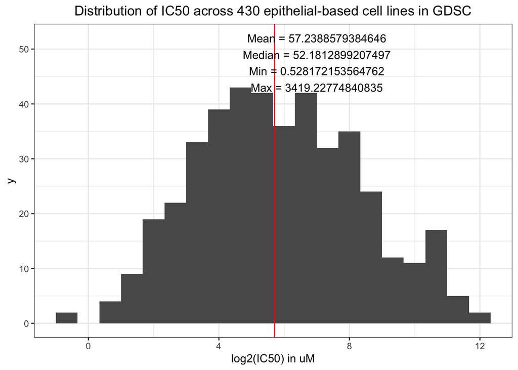

```r
ggplot(tidy_gdsc, aes(x = IC50)) +
  geom_histogram(bins = 20) +
  labs(title = "Distribution of IC50 across 430 epithelial-based cell lines in GDSC",
       x = "log2(IC50) in uM") +
  geom_vline(xintercept = median(tidy_gdsc$IC50), color = "red") +
  theme_bw() +
  annotate("text", x = 7, y = 52, label = paste("Mean =", 2^mean(tidy_gdsc$IC50))) +
  annotate("text", x = 7, y = 49, label = paste("Median =", 2^median(tidy_gdsc$IC50))) +
  annotate("text", x = 7, y = 46, label = paste("Min =", 2^min(tidy_gdsc$IC50))) +
  annotate("text", x = 7, y = 43, label = paste("Max =", 2^max(tidy_gdsc$IC50))) +
  theme(plot.title = element_text(hjust = 0.5))
```